# projectslides

## Quantile Regression: An Exploration of the 2023 Behavioral Risk Factor Screening Survey Data.

Authors: Hamilton Hewett and Laura Sikes

## Introduction: Regression Overview

- Regression is a method used to predict outcomes based on the behavior of variables within a dataset relative to a mean.
- Of an infinite number of lines that can be drawn through the data, the one best describing an overall relationship is the one with the smallest sum of the square of the errors.
- The errors measure the distance from each data point to the line, then each value is squared, and those squares are summed.
- The distances are squared in order to eliminate the negative properties of the distances that are found between the line and the data points below it.
- The line of best fit is one that produces the smallest sum of these squares.
- The formula for the regression line is

$$\hat{y} = \beta_0 + \beta_1 x$$

## Introduction: Regression Overview

In the regssion line equation

$$\hat{y} = \beta_0 + \beta_1 x$$
$$\beta_1 = \frac{n \sum x y - \sum x \sum y}{n \sum x^2 - \left(\sum x\right)^2}$$

The intercept $\beta_0$ is

$$\beta_0 = \frac{\sum y}{n} - \beta_1 \frac{\sum x}{n}$$
- Based on the above, predictions can be made about what would happen along the regression line where there are no data points.

## Introduction: Quantile Regression

- Quantile regression (QR) is a statistical approach that divides a distribution into different sections and finds the median point inside each one.
- This approach is especially useful when a distribution contains exceedingly high or low values, given that medians are not as influenced by extreme values as compared to means.
- QR is often an excellent solution when only one upper or lower end of a distribution contains a key variable.
- Variables may enjoy unique relationships within different sections of a distribution (Buhai, 2005).
- The equation for QR is

$$Q_Y(\tau \mid X) = X \beta(\tau)$$

- Q is the quantile function, τ represents the quantile of interest, Y is the response variable given the X predictor variable(s), β is the regression coefficient (Koenker, 2005).

## Introduction: Quantile Regression

- QR is a non-parametric method, meaning no assumptions are made about the sample size or the normality of the distribution (Cohen et al., 2016).
- Koenker and Machado (1999) identified the absence of a suitable goodness-of-fit assessment for this statistical method.
- The authors developed a method with inspiration from *R<sup>2</sup>*. *R<sup>2</sup>* is the coefficient of determination, which identifies the difference between the regression line and the mean.
- This coefficient’s values lie between 0 and 1, with values approaching 1 indicating ever-greater portions of the variation are explained by the relationship among the variables.

## Introduction: Quantile Regression, Goodness of Fit

The formula for *R<sup>2</sup>* is as follows:

$$R^2 = 1 - \frac{\sum \left(y_i - \hat{y}\right)^2}{\sum \left(y_i - \bar{y}\right)^2}$$

- The sum of observed values $y_i$ is subtracted by the sum of fitted values $\hat{y}$ and squared, forming the numerator.
- The sum of observed values $y_i$ minus the sum of sample mean $\bar{y}$ and then squared, forming the denominator.
- This formula may also be represented as

$$R^2 = 1 - \frac{RSS}{TSS}$$

where RSS is the residual sum of squares and TSS is the total sum of squares. - The post-hoc testing methods Koenker and Machado proposed are Δ<sub>n</sub>(τ), **W**<sub>n</sub>(τ), and T<sub>n</sub>(τ), which the authors claimed would vastly enhance the capacity for quantile regression inference. - The theory behind these methods is beyond the scope of this paper.

## Methodology: Study Design and Data

- Cross-sectional study using 2023 Behavioral Risk Factor Surveillance System (BRFSS) published by Centers for Disease Control and Prevention (CDC).
- Yearly survey conducted via landline and cellular telephone (CDC, 2024).
- Includes U.S. residents aged 18 years and older.
- Survery topics include demographic information, socioeconomic factors, physical and mental health status, chronic conditions, and behaviors affecting physical and mental health.

## Methodology: Response Variable - not sure how to incorporate both of ours here?

- Days per month a respondent’s poor health affected his or her activities of daily living (ADL)
- Respondents asked to quantify the number of days per month having poor mental or physical health interfered with their ability to conduct ADLs.
- Available responses were numeric values 1 – 30, none, refused, or don’t know/[not sure](https://github.com/les14uwf/notsure/blob/main/NOTSURE.png?raw=true).
- The authors note that quantile regression is a non-parametric method, meaning no assumptions are made about the sample size or the normality of the distribution.

## Predictor Variables - not sure how to incorporate both of ours here?

- Weight: Available responses including numeric values 50 – 776 in pounds, don’t know/not sure, refused, and a separate indicator for weight measured in kilograms.
- Education: Available responses included never attended school or only kindergarten, grades 1 through 8, grades 9 through 11, grade 12 or GED, 1 to 3 years of college, 4 years of college or more, and refused.
- Income in U.S. dollars: Available responses included <10,000, $10,000 to < $15,000, $15,000 to < $20,000, $20,000 to < $25,000, $25,000 to < $35,000, $35,000 to < $50,000, $50,000 to < $75,000, $75,000 to < $100,000, $100,000 to < $150,000, $150,000 to < $200,000, $200,000 or more, don’t know/not sure, and refused.
- Physical health: Number of days during the previous 30 days in which the respondant’s physical or mental health were not good, with available responses including numeric values 1 - 30, refused, or don’t know / not sure.
- Sex: Available responses were limited to male or female.

## Methodology: Operationalization of Variables - not sure how to incorporate both of ours here?

- Dataset filtered to include only residents of the state of Florida and removed of values containing “Refused,” “Not sure / Don’t know”, or missing.
- Response variable ADL was filtered to include only numeric responses, and recoded to four groups as follows: “1-7 Days”, “8-14 Days,” “15-21 Days”, and “>21 Days”.
- Education was recoded as follows: “Less than High School,”, “High School or GED,” “Some College”, and “4 Years of College or Higher.
- Income was recoded into six groups as follows: “<$25,000”, “$25,000-$34,999”, “$35,000-$49,000”, “$50,000-$74,999”, “$75,000-$99,999”, and “>$100,000”.
- Physical health and mental health were each recoded into four groups as follows: “1-7 Days”, “8-14 Days,” “15-21 Days”, and “>21 Days”.
- All statistical analyses were performed using RStudio version 2024.04.2, build 764, “Chocolate Cosmos” release for Windows (Posit Software, PBC, 2024).

## Results: Table 1a.

[output not shown]

## Results: Table 1b.

[output not shown]

## Results: Table 1c.

[output not shown]

## Results: Figure 1.

Weight in pounds.

[figure not shown]

## Results: Figure 2.

Linear regression: Mental health as a function of weight.

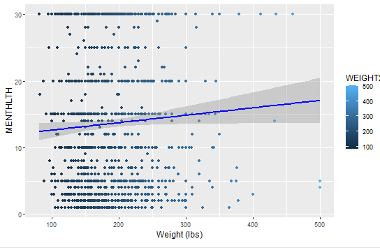

## Results: Figure 3.

Linear regression (blue) vs. quantile regression (green, tau=0.5): Mental health as a function of weight.

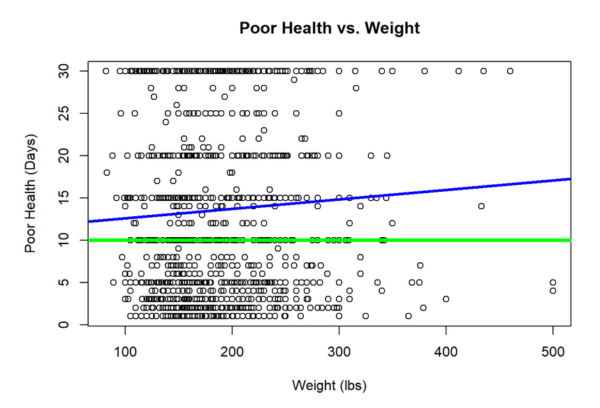

## Results: Figure 4.

Linear regression (blue) vs. quantile regression (black: tau=0.25; green: tau=0.5; yellow: tau=0.75): Mental health as a function of weight.

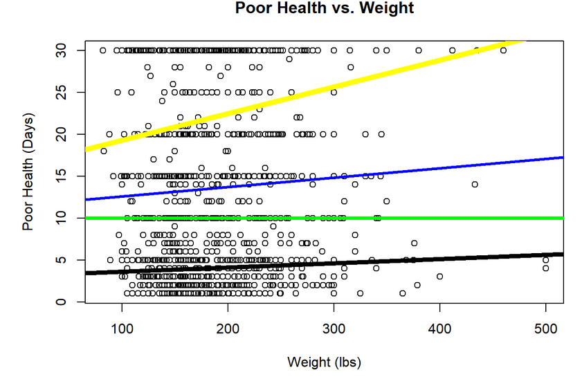

## References

Centers for Disease Control and Prevention (CDC). (2024). 2023 BRFSS Survey Data and Documentation. Retrieved October 12, 2024 from https://www.cdc.gov/brfss/annual_data/annual_2023.html

Posit Software, PBC. (2024). RStudio desktop. Retrieved October 13, 2024 from https://posit.co/download/rstudio-desktop/